# Análise exploratória de dados

Victor Abreu

08/12/2022

# Introdução

> Esta análise foi realizada no âmbito de …

Primeiro, comecemos por verificar se estamos a iniciar o nosso trabalho no diretório correcto:

```r
getwd()
```

```
## [1] "C:/Users/victo/Documents/Data & Analytics/Portfolio/analytics_reprex"
```

Este aspeto é crucial, até para garantir a correta reproducibilidade deste nosso projeto.

Importemos ainda o nosso *script* orientado para a **exploração** de dados:

```r
source("./misc/scripts/eda.R", encoding = 'UTF-8')
```

# Importação de dados

Efetuemos a importação dos dados exportados na fase anterior, através do comando `read.csv`, com posterior confirmação (e ajustando a natureza dos dados em cada coluna):

```r
iris.treino <- read.csv2("./pipeline/2_aed/iris_treino.csv", sep = ",")
```

```r
iris.treino$sepal.length <- as.numeric(iris.treino$sepal.length)
iris.treino$sepal.width <- as.numeric(iris.treino$sepal.width)
iris.treino$petal.length <- as.numeric(iris.treino$petal.length)
iris.treino$petal.width <- as.numeric(iris.treino$petal.width)

iris.treino$sepal.length.norm <- as.numeric(iris.treino$sepal.length.norm)
iris.treino$sepal.width.norm <- as.numeric(iris.treino$sepal.width.norm)
iris.treino$petal.length.norm <- as.numeric(iris.treino$petal.length.norm)
iris.treino$petal.width.norm <- as.numeric(iris.treino$petal.width.norm)
```

```r
head(iris.treino, n = 10)
```

```
##    sepal.length sepal.width petal.length petal.width sepal.length.norm
## 1           6.4         3.2          4.5         1.5         0.6176471
## 2           7.7         3.8          6.7         2.2         1.0000000
## 3           5.7         3.0          4.2         1.2         0.4117647
## 4           6.1         2.8          4.7         1.2         0.5294118
## 5           5.1         3.3          1.7         0.5         0.2352941
## 6           4.3         3.0          1.1         0.1         0.0000000
## 7           6.2         2.8          4.8         1.8         0.5588235
## 8           5.0         3.5          1.6         0.6         0.2058824
## 9           4.8         3.0          1.4         0.3         0.1470588
## 10          5.5         2.3          4.0         1.3         0.3529412
##    sepal.width.norm petal.length.norm petal.width.norm      class
## 1        0.45454545        0.60714286       0.58333333 versicolor
## 2        0.72727273        1.00000000       0.87500000  virginica
## 3        0.36363636        0.55357143       0.45833333 versicolor
## 4        0.27272727        0.64285714       0.45833333 versicolor
## 5        0.50000000        0.10714286       0.16666667     setosa
## 6        0.36363636        0.00000000       0.00000000     setosa
## 7        0.27272727        0.66071429       0.70833333  virginica
## 8        0.59090909        0.08928571       0.20833333     setosa
## 9        0.36363636        0.05357143       0.08333333     setosa
## 10       0.04545455        0.51785714       0.50000000 versicolor
```

```r
dim(iris.treino)
```

```
## [1] 48  9
```

```r
str(iris.treino)
```

```
## 'data.frame':    48 obs. of  9 variables:
##  $ sepal.length     : num  6.4 7.7 5.7 6.1 5.1 4.3 6.2 5 4.8 5.5 ...
##  $ sepal.width      : num  3.2 3.8 3 2.8 3.3 3 2.8 3.5 3 2.3 ...
##  $ petal.length     : num  4.5 6.7 4.2 4.7 1.7 1.1 4.8 1.6 1.4 4 ...
##  $ petal.width      : num  1.5 2.2 1.2 1.2 0.5 0.1 1.8 0.6 0.3 1.3 ...
##  $ sepal.length.norm: num  0.618 1 0.412 0.529 0.235 ...
##  $ sepal.width.norm : num  0.455 0.727 0.364 0.273 0.5 ...
##  $ petal.length.norm: num  0.607 1 0.554 0.643 0.107 ...
##  $ petal.width.norm : num  0.583 0.875 0.458 0.458 0.167 ...
##  $ class            : chr  "versicolor" "virginica" "versicolor" "versicolor" ...
```

# Análises univariadas

No campo da exploração propriamente dito, comecemos por estudar o comportamento de cada uma das variáveis do nosso (potencial) interesse, ainda antes de verificarmos se existem (ou não) possíveis relações de interesse entre as mesmas.

```r
eda.rmd.table.display(eda.univariate.numeric.stats(iris.treino$sepal.length, desc = "Comprimento das sépalas (em cm)", na.rm = TRUE, digits = 3), mode = "HTML")
```

```
##                      Comprimento das sépalas (em cm)
## no.obs                                        48.000
## mean                                           5.728
## median                                         5.700
## mode                                           5.700
## variance                                       0.654
## std.deviation                                  0.809
## std.error                                      0.117
## coef.variation                                 0.141
## first.quartile                                 5.075
## third.quartile                                 6.300
## inter.quartile.range                           1.225
## minimum                                        4.300
## maximum                                        7.700
## abs.range                                      3.400
## skewness                                       0.372
## kurtosis                                       2.843
```

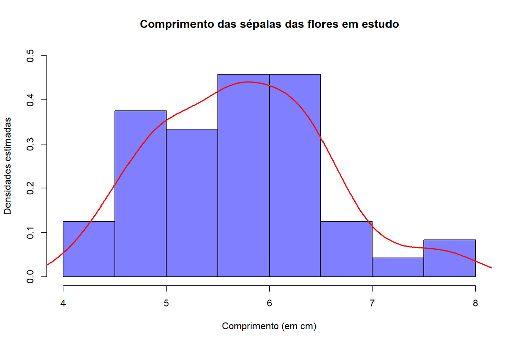

```r
eda.univariate.numeric.plots(iris.treino$sepal.length, main = "Comprimento das sépalas das flores em estudo", sub = "", xlab = "Comprimento (em cm)", ylab = "Densidades estimadas", xlim = c(4, 8), ylim = c(0, 0.5), bars.col = blue.palette.dark[5], line.col = color.palette[1], lwd = 2, breaks = 10)
```

De notar que:

1. De uma forma geral, o comprimento das sépalas se encontra entre os 5.1 e os 6.3 centímetros, sendo que o cenário mais comum é aquele onde estas medem cerca de 5.7 $cm$;
2. Tenhamos também em mente, para evitar possíveis erros de extrapolação na construção de futuros modelos, que todas as medições pertencem ao intervalo $[4.3 cm; 7.7cm]$;
3. Não há muita dispersão nestas medições;
4. A dispersão que de facto existe não tem uma tendência definida nem se acumula numa cauda (isto é, a distribuição parece ser razoavelmente simétrica), nem é causada por valores extremos (dado que a curtose não assume valores elevados).

```r
eda.rmd.table.display(eda.univariate.numeric.stats(iris.treino$sepal.width, desc = "Largura das sépalas (em cm)", na.rm = TRUE, digits = 3), mode = "HTML")
```

```
##                      Largura das sépalas (em cm)
## no.obs                                    48.000
## mean                                       3.042
## median                                     3.000
## mode                                       3.000
## variance                                   0.219
## std.deviation                              0.468
## std.error                                  0.067
## coef.variation                             0.154
## first.quartile                             2.800
## third.quartile                             3.300
## inter.quartile.range                       0.500
## minimum                                    2.200
## maximum                                    4.400
## abs.range                                  2.200
## skewness                                   0.835
## kurtosis                                   4.230
```

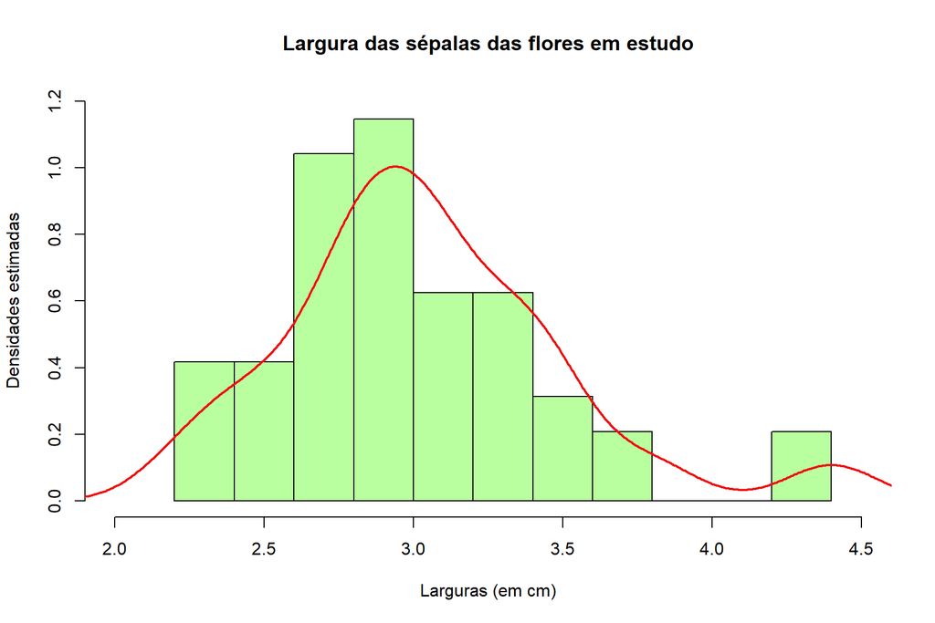

```r
eda.univariate.numeric.plots(iris.treino$sepal.width, main = "Largura das sépalas das flores em estudo", sub = "", xlab = "Larguras (em cm)", ylab = "Densidades estimadas", xlim = c(2, 4.5), ylim = c(0, 1.2), bars.col = green.palette[6], line.col = color.palette[1], lwd = 2, breaks = 8)
```

De destacar ainda a existência de uma “ilha” composta por duas observações onde ´sepal.width == 4.4´.

```r
eda.rmd.table.display(eda.univariate.numeric.stats(iris.treino$petal.length, desc = "Comprimento das pétalas (em cm)", na.rm = TRUE, digits = 3), mode = "HTML")
```

```
##                      Comprimento das pétalas (em cm)
## no.obs                                        48.000
## mean                                           3.646
## median                                         4.250
## mode                                           1.400
## variance                                       3.123
## std.deviation                                  1.767
## std.error                                      0.255
## coef.variation                                 0.485
## first.quartile                                 1.575
## third.quartile                                 5.000
## inter.quartile.range                           3.425
## minimum                                        1.100
## maximum                                        6.700
## abs.range                                      5.600
## skewness                                      -0.226
## kurtosis                                       1.593
```

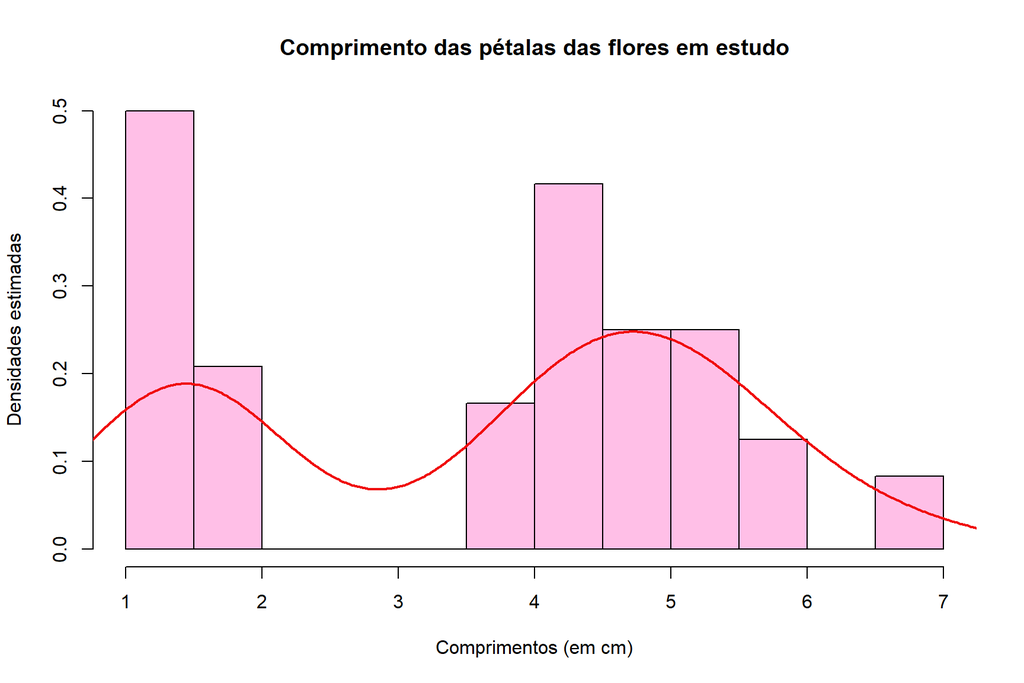

```r
eda.univariate.numeric.plots(iris.treino$petal.length, main = "Comprimento das pétalas das flores em estudo", sub = "", xlab = "Comprimentos (em cm)", ylab = "Densidades estimadas", xlim = c(1, 7), ylim = c(0, 0.5), bars.col = pink.palette[7], line.col = color.palette[1], lwd = 2, breaks = 8)
```

De notar que:

1. De uma forma geral, o comprimento das pétalas se encontra entre os 1.6 e os 5 centímetros e, mais concretamente, estas tendem a medir entre 3.7 a 4.3 $cm$;
2. Apesar disto, o mais comum é encontrarmos pétalas curtas, de $1.4 cm$, sendo que na verdade existem três tipos de pétalas: curtas (entre 1 e 2 cm), médias (entre 3.5 a 6 cm), e longas (6.5 a 7 cm);
3. Tenhamos também em mente, para evitar possíveis erros de extrapolação na construção de futuros modelos, que todas as medições pertencem ao intervalo $[1.1 cm; 6.7cm]$;
4. Agora existe uma maior dispersão nos dados;
5. A dispersão existente não tem, mais uma vez, uma tendência definida nem se acumula numa cauda (isto é, a distribuição parece ser razoavelmente simétrica), nem é causada por valores extremos (dado que a curtose não assume valores elevados).

```r
eda.rmd.table.display(eda.univariate.numeric.stats(iris.treino$petal.width, desc = "Largura das pétalas (em cm)", na.rm = TRUE, digits = 3), mode = "HTML")
```

```
##                      Largura das pétalas (em cm)
## no.obs                                    48.000
## mean                                       1.163
## median                                     1.300
## mode                                       0.200
## variance                                   0.543
## std.deviation                              0.737
## std.error                                  0.106
## coef.variation                             0.634
## first.quartile                             0.375
## third.quartile                             1.725
## inter.quartile.range                       1.350
## minimum                                    0.100
## maximum                                    2.500
## abs.range                                  2.400
## skewness                                  -0.054
## kurtosis                                   1.695
```

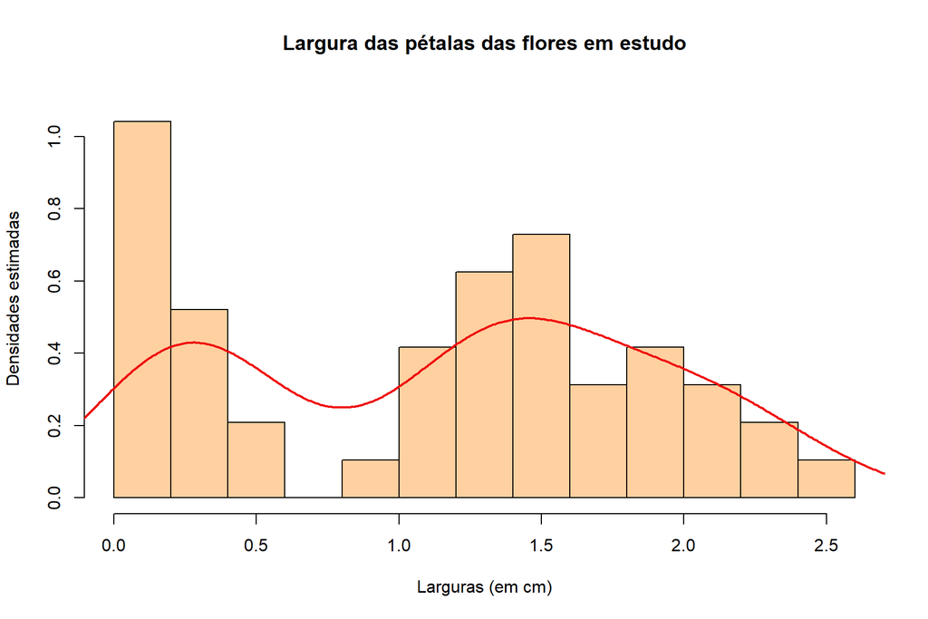

[output not shown]

```r
eda.univariate.numeric.plots(iris.treino$petal.width, main = "Largura das pétalas das flores em estudo", sub = "", xlab = "Larguras (em cm)", ylab = "Densidades estimadas", xlim = c(0, 2.6), ylim = c(0, 1.1), bars.col = orange.palette[6], line.col = color.palette[1], lwd = 2, breaks = 10)
```

De notar que:

1. De uma forma geral, a largura das pétalas se encontra entre os 0.4 e os 1.8 centímetros e, mais concretamente, estas tendem a medir entre 1.1 a 1.3 $cm$;
2. Apesar disto, o mais comum é encontrarmos pétalas menos largas (até 0.6 cm, sobretudo perto de 0.2 cm) ou mais largas (a partir de 0.8 cm);
3. Tenhamos também em mente, para evitar possíveis erros de extrapolação na construção de futuros modelos, que todas as medições pertencem ao intervalo $[0.1 cm; 2.5cm]$;
4. Agora existe uma maior dispersão nos dados;
5. A dispersão existente não tem, mais uma vez, uma tendência definida nem se acumula numa cauda (isto é, a distribuição parece ser razoavelmente simétrica), nem é causada por valores extremos (dado que a curtose não assume valores elevados).

# Análises multivariadas

Uma vez dissecado o nosso conjunto de dados numa análise univariada, podemos passar para análises multivariadas, sobretudo bivariadas.

Sendo o nosso interesse o de prever `species`, devemos ter cuidado com uma potencial colinearidade das features que nos irão auxiliar nessa tarefa. Nesse sentido, eis a seguinte matriz de correlações (de Pearson):

```r
cor(iris.treino[, 1:4])
```

```
##              sepal.length sepal.width petal.length petal.width
## sepal.length    1.0000000  -0.1271713    0.8758057   0.8154975
## sepal.width    -0.1271713   1.0000000   -0.4426190  -0.3677724
## petal.length    0.8758057  -0.4426190    1.0000000   0.9569325
## petal.width     0.8154975  -0.3677724    0.9569325   1.0000000
```

Podemos notar desde já que suspeitamos que `sepal.length`, `petal.length` e `petal.width` são variáveis que se irão comportar de forma similar, por contraste com `sepal.width`, mais independente. De facto,

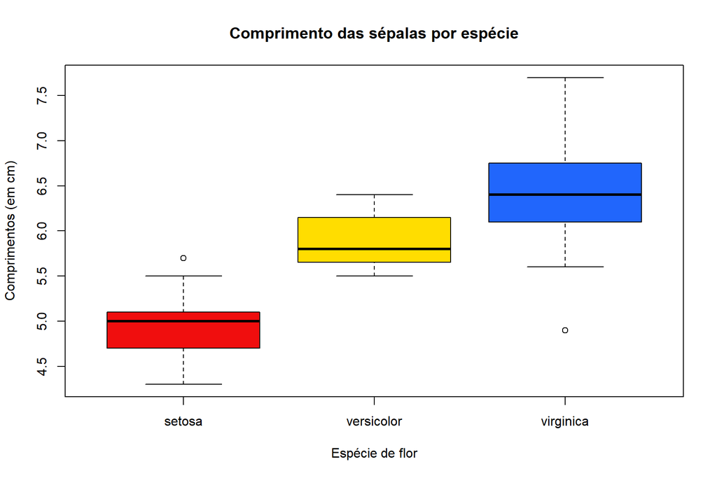

```r
eda.conditional.numeric.groupby.plots(iris.treino$sepal.length, iris.treino$class, k = 1.5, main = "Comprimento das sépalas por espécie", xlab = "Espécie de flor", ylab = "Comprimentos (em cm)", box.col = color.palette[c(1, 4, 9)])
```

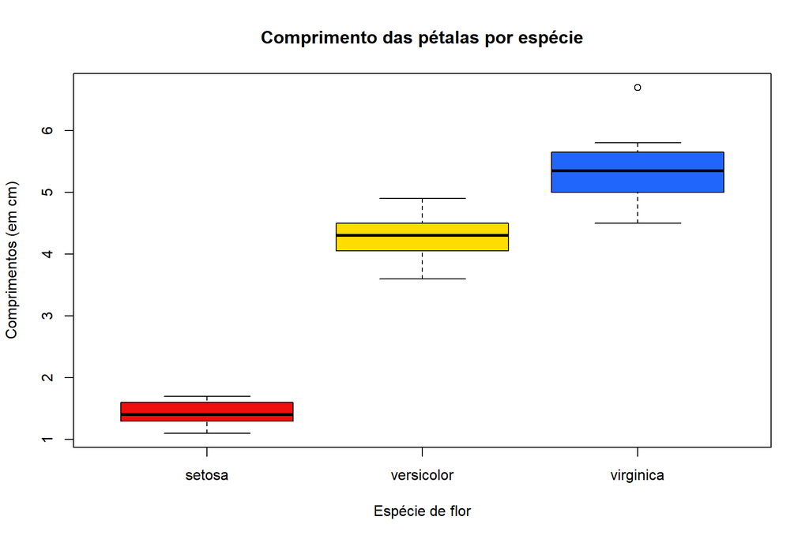

```r
eda.conditional.numeric.groupby.plots(iris.treino$petal.length, iris.treino$class, k = 1.5, main = "Comprimento das pétalas por espécie", xlab = "Espécie de flor", ylab = "Comprimentos (em cm)", ylim = NULL, box.col = color.palette[c(1, 4, 9)])
```

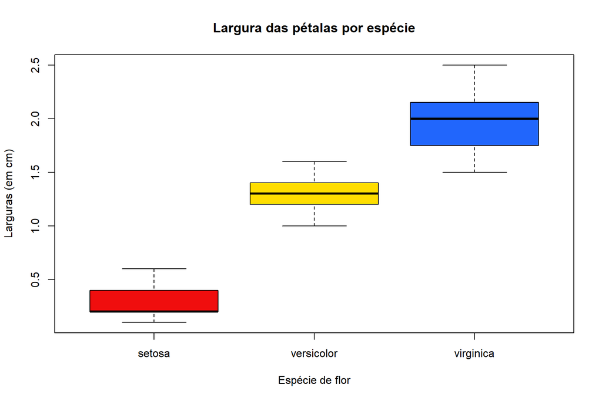

```r
eda.conditional.numeric.groupby.plots(iris.treino$petal.width, iris.treino$class, k = 1.5, main = "Largura das pétalas por espécie", xlab = "Espécie de flor", ylab = "Larguras (em cm)", ylim = NULL, box.col = color.palette[c(1, 4, 9)])
```

De notar, de forma geral, que sendo o objetivo destas visualizações o de permitir comparações, não constitui problema o facto do eixo vertical não ter início no 0.

Dada a similaridade entre estas variáveis explicativas, as relações entre cada uma delas e a espécie da planta serão também similares; em todas elas notamos que a espécie `setosa` está associada a menores medições, e que `virginica` pode ser caraterizada por maiores medições, estando `versicolor` algures no meio.

Por isso, e sem perda de generalidade, escolhamos apenas `petal.length`:

```r
eda.conditional.numeric.groupby.stats(iris.treino$petal.length, iris.treino$class)
```

```
##   factor/group no.obs     mean   variance std.deviation minimum first.quartile
## 1       setosa     17 1.435294 0.02617647     0.1617914     1.1           1.30
## 2   versicolor     15 4.260000 0.12828571     0.3581700     3.6           4.05
## 3    virginica     16 5.418750 0.37095833     0.6090635     4.5           5.00
##   median third.quartile maximum inter.quartile.range abs.range skewness
## 1   1.40          1.600     1.7                0.300       1.1   -0.321
## 2   4.30          4.500     4.9                0.450       3.6   -0.221
## 3   5.35          5.625     6.7                0.625       4.5    0.898
##   kurtosis  std.error coef.variation
## 1    2.386 0.03924019     0.11272355
## 2    2.447 0.09247908     0.08407745
## 3    3.320 0.15226587     0.11239926
```

Por contraste, ter-se-á:

```r
eda.conditional.numeric.groupby.stats(iris.treino$sepal.width, iris.treino$class)
```

```
##   factor/group no.obs     mean  variance std.deviation minimum first.quartile
## 1       setosa     17 3.405882 0.1905882     0.4365641     3.0          3.100
## 2   versicolor     15 2.773333 0.1006667     0.3172801     2.3          2.550
## 3    virginica     16 2.906250 0.1459583     0.3820449     2.2          2.775
##   median third.quartile maximum inter.quartile.range abs.range skewness
## 1    3.3          3.500     4.4                 0.40       3.0    1.320
## 2    2.8          2.950     3.4                 0.40       2.3    0.141
## 3    2.8          3.025     3.8                 0.25       2.2    0.499
##   kurtosis  std.error coef.variation
## 1    3.840 0.10588235      0.1281794
## 2    2.413 0.08192137      0.1144039
## 3    3.434 0.09551123      0.1314563
```

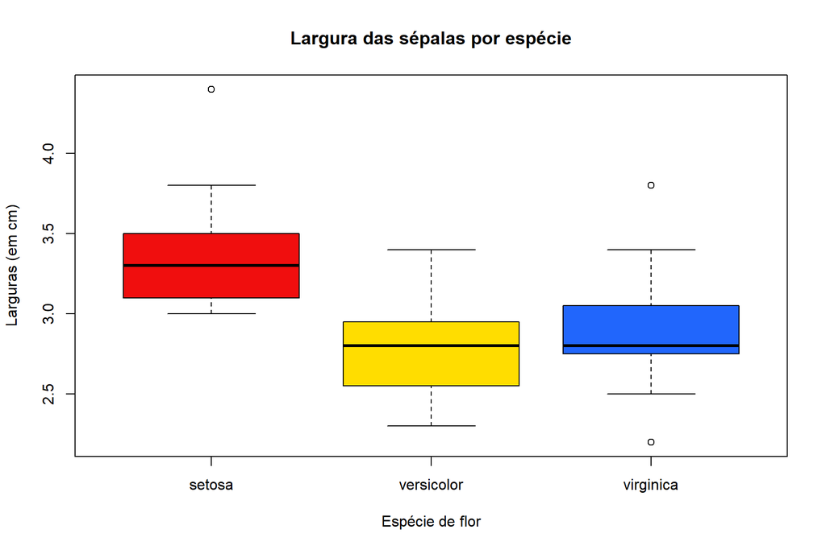

```r
eda.conditional.numeric.groupby.plots(iris.treino$sepal.width, iris.treino$class, k = 1.5, main = "Largura das sépalas por espécie", xlab = "Espécie de flor", ylab = "Larguras (em cm)", ylim = NULL, box.col = color.palette[c(1, 4, 9)])
```

Observamos, tanto de forma visual como de forma numérica, que:

1. As plantas da espécie `setosa` têm sépalas mais largas, em adição ao que já vimos anteriormente (pétalas menos compridas, isto é, mais curtas);
2. De seguida, embora já a alguma distância, são as plantas da espécie `virginica` as que apresentam as sépalas mais extensas;
3. Por último, e também por exclusão de partes, são as plantas da espécie `versicolor` as que apresentam menores sépalas (salvo raras excepções).

Em ambas as análises, os graus de dispersão relativa das medições são similares entre espécies.

# Impressões finais

Uma breve análise à matriz de correlações apresentada sugere que provavelmente será boa ideia utilizar apenas duas *features*: `sepal.width` e mais uma de entre as outras 3. Tendo em conta a natureza das medições, bem como a dispersão das mesmas, talvez seja interessante escolher como segundo preditor `petal.length`.